# QTL Mapping of ERA8

2019.09.17

**Title**: Exome sequencing of bulked segregants identified a novel *TaMKK3-A* allele linked to the wheat *ERA8* ABA-hypersensitive germination phenotype

**Authors**: Shantel A. Martinez, Oluwayesi Shorinola, Samantha Conselman, Deven See, Daniel Z. Skinner, Cristobal Uauy, and Camille M. Steber

This document contains all datasets on which the conclusions of the paper, Martinez et al. 2020, to enable reproducibility of the QTL Mapping.

The datasets generated during and/or analysed during the current study are available in the GitHub repository, github.com/shantel-martinez/ERA8-Mapping.

#### Load All Data

Once downloaded, the environment can be loaded:

```r
load("./ERA8-Mapping-Data.RData")
```

#### Load Libraries

```r
library(qtl)
library(ggplot2)
font<-element_text(face = "bold",  size = 16) #ggplot preference
library(tidyverse)
library(kableExtra)
library(knitr)
library(DT)
```

## Zak/ZakERA8 BC3F2:3

The `ZZ8` dataset contains Zak/ZakERA8 BC3 F2:3 genotypic data, phenotypic data, and marker positions on chromosome 4A.

```r
ZZ8 <- read.cross("csv",".","./ZZ8_SNP1-SNP_30_all.csv",na.strings=c("-","NA","."),BC.gen=3, F.gen=2)
```

```
##   This is an object of class "cross".
##   It is too complex to print, so we provide just this summary.
##     BC(3)F(2) cross
##
##     No. individuals:    424
##
##     No. phenotypes:     3
##     Percent phenotyped: 100 97.9 97.9
##
##     No. chromosomes:    1
##         Autosomes:      4A
##
##     Total markers:      11
##     No. markers:        11
##     Percent genotyped:  92.6
##     Genotypes (%):      AA:27.9  AB:51.9  BB:20.2  not BB:0.0  not AA:0.0
```

Phenotypes include: Percent Germination (`PG`) and Germination Index (`GI`)

#### Composite Interval Mapping

```r
data_2 <- calc.genoprob(ZZ8, step=0)
out.cimPGavg <- cim(data_2, pheno.col="PG",map.function=c("kosambi"),method=c("hk"))
out.cimPGavg$Trait <- ("PG")
out.cimGIavg <- cim(data_2, pheno.col="GI",map.function=c("kosambi"),method=c("hk"))
out.cimGIavg$Trait <- ("GI")
```

#### Determine Significance Threshhold

```r
a <- scanone(ZZ8, method="hk", pheno.col = "PG", n.perm=1000)
b <- scanone(ZZ8, method="hk", pheno.col = "GI", n.perm=1000)
summary(a)
summary(b)
```

#### Wrangle Results

```r
ZZ8_all <- rbind(out.cimPGavg, out.cimGIavg)
ZZ8_all$Population <- ("all")
```

**Repeat CIM for the X5.1 subset only**

```r
data5.1<-read.cross("csv",".","./ZZ8_SNP1-SNP_30_5.1.csv",na.strings=c("-","NA","."),BC.gen=3, F.gen=2)
```

```
##   This is an object of class "cross".
##   It is too complex to print, so we provide just this summary.
##     BC(3)F(2) cross
##
##     No. individuals:    122
##
##     No. phenotypes:     3
##     Percent phenotyped: 100 94.3 94.3
##
##     No. chromosomes:    1
##         Autosomes:      4A
##
##     Total markers:      11
##     No. markers:        11
##     Percent genotyped:  91.7
##     Genotypes (%):      AA:28.1  AB:53.7  BB:18.2  not BB:0.0  not AA:0.0
```

```r
data_2 <- calc.genoprob(data5.1, step=0)
out.cimPGavg <- cim(data_2, pheno.col="PG",map.function=c("kosambi"),method=c("hk"))
out.cimPGavg$Trait <- ("PG")
out.cimGIavg <- cim(data_2, pheno.col="GI",map.function=c("kosambi"),method=c("hk"))
a <- scanone(data5.1, method="hk", pheno.col = "PG", n.perm=1000)
b <- scanone(data5.1, method="hk", pheno.col = "GI", n.perm=1000)
summary(a)
summary(b)
ZZ8_5.1 <- rbind(out.cimPGavg, out.cimGIavg)
ZZ8_5.1$Population <- ("5.1")
```

**Repeat CIM for the X5.2a subset only**

```r
data5.2a<-read.cross("csv",".","./ZZ8_SNP1-SNP_30_5.2a.csv",na.strings=c("-","NA","."),BC.gen=3, F.gen=2)
```

```
##   This is an object of class "cross".
##   It is too complex to print, so we provide just this summary.
##     BC(3)F(2) cross
##
##     No. individuals:    242
##
##     No. phenotypes:     3
##     Percent phenotyped: 100 99.2 99.2
##
##     No. chromosomes:    1
##         Autosomes:      4A
##
##     Total markers:      11
##     No. markers:        11
##     Percent genotyped:  93.2
##     Genotypes (%):      AA:27.6  AB:50.8  BB:21.5  not BB:0.0  not AA:0.0
```

```r
data_2 <- calc.genoprob(data5.2a, step=0)
out.cimPGavg <- cim(data_2, pheno.col="PG",map.function=c("kosambi"),method=c("hk"))
out.cimPGavg$Trait <- ("PG")
out.cimGIavg <- cim(data_2, pheno.col="GI",map.function=c("kosambi"),method=c("hk"))
out.cimGIavg$Trait <- ("GI")
a <- scanone(data5.2a, method="hk", pheno.col = "PG", n.perm=1000)
b <- scanone(data5.2a, method="hk", pheno.col = "GI", n.perm=1000)
summary(a)
summary(b)
ZZ8_5.2a <- rbind(out.cimPGavg, out.cimGIavg)
ZZ8_5.2a$Population <- ("5.2a")
```

**Repeat CIM for the X5.2b subset only**

```r
data5.2b <- read.cross("csv",".","./ZZ8_SNP1-SNP_30_5.2b.csv",na.strings=c("-","NA","."),BC.gen=3, F.gen=2)
```

```
##   This is an object of class "cross".
##   It is too complex to print, so we provide just this summary.
##     BC(3)F(2) cross
##
##     No. individuals:    60
##
##     No. phenotypes:     3
##     Percent phenotyped: 100 100 100
##
##     No. chromosomes:    1
##         Autosomes:      4A
##
##     Total markers:      11
##     No. markers:        11
##     Percent genotyped:  92
##     Genotypes (%):      AA:28.8  AB:52.6  BB:18.6  not BB:0.0  not AA:0.0
```

```r
data_2 <- calc.genoprob(data5.2b, step=0)
out.cimPGavg <- cim(data_2, pheno.col="PG",map.function=c("kosambi"),method=c("hk"))
out.cimPGavg$Trait <- ("PG")
out.cimGIavg <- cim(data_2, pheno.col="GI",map.function=c("kosambi"),method=c("hk"))
out.cimGIavg$Trait <- ("GI")
a <- scanone(data5.2b, method="hk", pheno.col = "PG", n.perm=1000)
b <- scanone(data5.2b, method="hk", pheno.col = "GI", n.perm=1000)
summary(a)
summary(b)
ZZ8_5.2b <- rbind(out.cimPGavg, out.cimGIavg)
ZZ8_5.2b$Population <- ("5.2b")
```

#### Graph Results

QTL Graph for Germination Index (`GI`)

```r
ZZ8_QTL <- rbind(ZZ8_all, ZZ8_5.1, ZZ8_5.2b, ZZ8_5.2a)
GI <- ZZ8_QTL[(ZZ8_QTL$Trait %in% "GI"),]

ggplot(data = GI , aes(x=GI$pos, y=GI$lod)) +
  geom_line(aes(colour=GI$Population), size=1)+geom_hline(aes(yintercept = 1.85))+
  theme_bw()+ theme(axis.text = font,  axis.title = font)+
  labs(x = "Chromosome 4A ERA8 Region (cM)", y = "LOD")+
  scale_color_manual(values=c("#78c679", "#006837", "#31a354","#A2CD5A")) #+ theme(legend.position="none") +
  # ggsave("ZZ8_4A_QTL.png", width = 3, height = 3, units = "in")
```

## Fig 3a

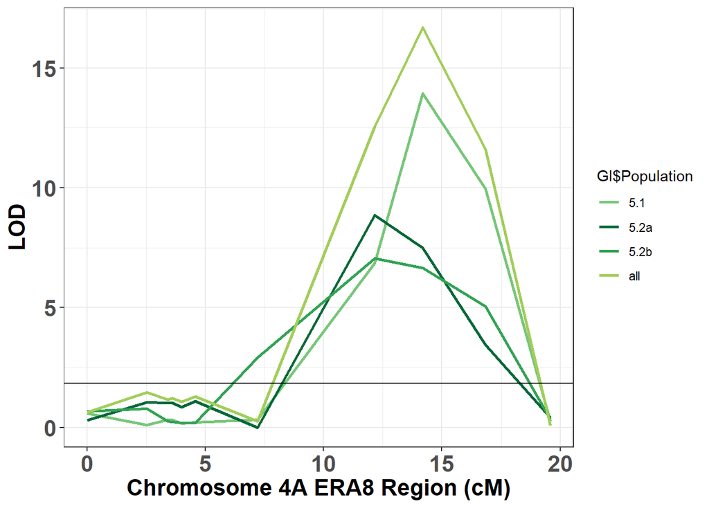

## Louise/ZakERA8 RIL F6:7

### EMS-derived SNPs

```r
# LZ8 <- read.cross("csv",".","./LZ8_SNP1-SNP30_MKK3.csv",na.strings=c("-","NA","."),BC.gen=0, F.gen=5)
LZ8
```

```
##   This is an object of class "cross".
##   It is too complex to print, so we provide just this summary.
##     BC(0)F(5) cross
##
##     No. individuals:    207
##
##     No. phenotypes:     21
##     Percent phenotyped: 100 100 100 100 100 100 100 88.9 88.9 88.4 88.4
##                         82.1 82.1 84.5 84.1 84.5 84.5 84.5 83.6 99.5 99.5
##
##     No. chromosomes:    1
##         Autosomes:      4A
##
##     Total markers:      13
##     No. markers:        13
##     Percent genotyped:  92.7
##     Genotypes (%):      AA:50.1  AB:5.5  BB:44.4  not BB:0.0  not AA:0.0
```

```r
data_2 <- calc.genoprob(data5.2b, step=0)
data_2 <- calc.genoprob(LZ8, step=0)

out.cimE1PGD1 <- cim(data_2, pheno.col="E1D1",map.function=c("kosambi"),method=c("hk"))
out.cimE1PGD1$Trait <- ("E1PGD1")
out.cimE1PGD2 <- cim(data_2, pheno.col="E1D2",map.function=c("kosambi"),method=c("hk"))
out.cimE1PGD2$Trait <- ("E1PGD2")
out.cimE1PGD3 <- cim(data_2, pheno.col="E1D3",map.function=c("kosambi"),method=c("hk"))
out.cimE1PGD3$Trait <- ("E1PGD3")
out.cimE1PGD4 <- cim(data_2, pheno.col="E1D4",map.function=c("kosambi"),method=c("hk"))
out.cimE1PGD4$Trait <- ("E1PGD4")
out.cimE1PGD5 <- cim(data_2, pheno.col="E1D5",map.function=c("kosambi"),method=c("hk"))
out.cimE1PGD5$Trait <- ("E1PGD5")
out.cimE1GIavg <- cim(data_2, pheno.col="E1GI",map.function=c("kosambi"),method=c("hk"))
out.cimE1GIavg$Trait <- ("E1GIavg")

out.cimE2PGD1 <- cim(data_2, pheno.col="E2D1",map.function=c("kosambi"),method=c("hk"))
out.cimE2PGD1$Trait <- ("E2PGD1")
out.cimE2PGD2 <- cim(data_2, pheno.col="E2D2",map.function=c("kosambi"),method=c("hk"))
out.cimE2PGD2$Trait <- ("E2PGD2")
out.cimE2PGD3 <- cim(data_2, pheno.col="E2D3",map.function=c("kosambi"),method=c("hk"))
out.cimE2PGD3$Trait <- ("E2PGD3")
out.cimE2PGD4 <- cim(data_2, pheno.col="E2D4",map.function=c("kosambi"),method=c("hk"))
out.cimE2PGD4$Trait <- ("E2PGD4")
out.cimE2PGD5 <- cim(data_2, pheno.col="E2D5",map.function=c("kosambi"),method=c("hk"))
out.cimE2PGD5$Trait <- ("E2PGD5")
out.cimE2GIavg <- cim(data_2, pheno.col="E2GI",map.function=c("kosambi"),method=c("hk"))
out.cimE2GIavg$Trait <- ("E2GIavg")

out.cimE3PGD1 <- cim(data_2, pheno.col="E3D1",map.function=c("kosambi"),method=c("hk"))
out.cimE3PGD1$Trait <- ("E3PGD1")
out.cimE3PGD2 <- cim(data_2, pheno.col="E3D2",map.function=c("kosambi"),method=c("hk"))
out.cimE3PGD2$Trait <- ("E3PGD2")
out.cimE3PGD3 <- cim(data_2, pheno.col="E3D3",map.function=c("kosambi"),method=c("hk"))
out.cimE3PGD3$Trait <- ("E3PGD3")
out.cimE3PGD4 <- cim(data_2, pheno.col="E3D4",map.function=c("kosambi"),method=c("hk"))
out.cimE3PGD4$Trait <- ("E3PGD4")
out.cimE3PGD5 <- cim(data_2, pheno.col="E3D5",map.function=c("kosambi"),method=c("hk"))
out.cimE3PGD5$Trait <- ("E3PGD5")
out.cimE3GIavg <- cim(data_2, pheno.col="E3GI",map.function=c("kosambi"),method=c("hk"))
out.cimE3GIavg$Trait <- ("E3GIavg")

QTL.LZ8.ERA8 <- rbind(out.cimE1PGD1, out.cimE1PGD2, out.cimE1PGD3, out.cimE1PGD4, out.cimE1PGD5,
                      out.cimE1GIavg, out.cimE2PGD1, out.cimE2PGD2, out.cimE2PGD3, out.cimE2PGD4,
                      out.cimE2PGD5, out.cimE2GIavg,out.cimE3PGD1, out.cimE3PGD2, out.cimE3PGD3,
                      out.cimE3PGD4, out.cimE3PGD5, out.cimE3GIavg)
QTL.LZ8.Day1 <- rbind(out.cimE1PGD1, out.cimE2PGD1,out.cimE3PGD1)
QTL.LZ8.GI <- rbind(out.cimE1GIavg, out.cimE2GIavg,out.cimE3GIavg)
```

Calculating the significant LOD score threshold for each trait

```r
a<-scanone(LZ8, method="hk", pheno.col = "E1D1", n.perm=1000)
c<-scanone(LZ8, method="hk", pheno.col = "E1D2", n.perm=1000)
d<-scanone(LZ8, method="hk", pheno.col = "E1D3", n.perm=1000)
e<-scanone(LZ8, method="hk", pheno.col = "E1D4", n.perm=1000)
f<-scanone(LZ8, method="hk", pheno.col = "E1D5", n.perm=1000)
g<-scanone(LZ8, method="hk", pheno.col = "E1GI", n.perm=1000)
b1<-scanone(LZ8, method="hk", pheno.col = "E2D1", n.perm=1000)
c1<-scanone(LZ8, method="hk", pheno.col = "E2D2", n.perm=1000)
d1<-scanone(LZ8, method="hk", pheno.col = "E2D3", n.perm=1000)
e1<-scanone(LZ8, method="hk", pheno.col = "E2D4", n.perm=1000)
f1<-scanone(LZ8, method="hk", pheno.col = "E2D5", n.perm=1000)
g1<-scanone(LZ8, method="hk", pheno.col = "E2GI", n.perm=1000)
h<-scanone(LZ8, method="hk", pheno.col = "E3D1", n.perm=1000)
i<-scanone(LZ8, method="hk", pheno.col = "E3D2", n.perm=1000)
j<-scanone(LZ8, method="hk", pheno.col = "E3D3", n.perm=1000)
k<-scanone(LZ8, method="hk", pheno.col = "E3D4", n.perm=1000)
l<-scanone(LZ8, method="hk", pheno.col = "E3D5", n.perm=1000)
m<-scanone(LZ8, method="hk", pheno.col = "E3GI", n.perm=1000)
summary(a) #2.12 E1D1
summary(c) #2.10
summary(d) #2.20
summary(e) #2.15
summary(f) #2.02
summary(g) #1.98
summary(b1) #2.06 E2D1
summary(c1) #2.17
summary(d1) #2.03
summary(e1) #1.96
summary(f1) #2.17
summary(g1) #2.10
summary(h) #2.01 E3D1
summary(i) #2.01
summary(j) #2.21
summary(k) #2.12
summary(l) #2.11
summary(m) #2.19
```

QTL Graph for GI

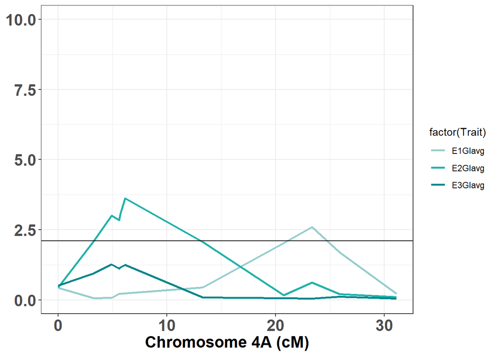

```r
ggplot(QTL.LZ8.GI, aes(x=QTL.LZ8.GI$pos, y=QTL.LZ8.GI$lod))+
  geom_line(aes(colour = factor(Trait)),size = 1)+
  theme_bw()+ theme(axis.text = font,  axis.title = font)+
  geom_hline(aes(yintercept = 2.10))+
  labs(x = "Chromosome 4A (cM)", y = NULL) +
  ylim (0,10) +
  scale_color_manual(values=c("#96CDCD", "#20B2AA", "#00868B")) #+ theme(legend.position="none") #+
```

```r
  # ggsave("LZ8_4A_QTL.png", width = 3, height = 3, units = "in")
```

### Genotyping-by-sequencing SNPs

```r
# LZ8GBS <- read.cross("csv",".","./LZ8_GBS_all.csv",na.strings=c("-","NA","."),BC.gen=0, F.gen=5)
LZ8GBS
```

```
##   This is an object of class "cross".
##   It is too complex to print, so we provide just this summary.
##     BC(0)F(5) cross
##
##     No. individuals:    209
##
##     No. phenotypes:     21
##     Percent phenotyped: 99 99 99 99 99 99 99 88 88 87.6 87.6 81.3 81.3 83.7
##                         83.3 83.7 83.7 83.7 82.8 98.6 98.6
##
##     No. chromosomes:    45
##         Autosomes:      1A.1 1B.1 1B.2 1B.3 1D.1 1D.2 2A.1 2A.2 2B.1 2D.1
##                         3A.1 3A.2 3A.3 3A.4 3B.1 3D.1 3D.2 4A.1 4A.2 4A.3
##                         4B.1 4B.2 4D.1 5A.1 5A.2 5B.1 5B.2 5B.3 5D.1 5D.2
##                         6A.1 6A.2 6B.1 6B.2 6D.1 6D.2 6D.3 7A.1 7A.2 7B.1
##                         7B.2 7D.1 7D.2 7D.3 UNK.1
##
##     Total markers:      2234
##     No. markers:        231 132 6 9 8 49 14 84 49 57 80 41 5 54 64 19 27
##                         127 92 5 124 6 11 54 8 66 13 5 18 9 129 40 19 20 16
##                         13 5 106 132 201 5 20 8 33 20
##     Percent genotyped:  99
##     Genotypes (%):      AA:45.2  AB:3.5  BB:51.4  not BB:0.0  not AA:0.0
```

View genotypic data

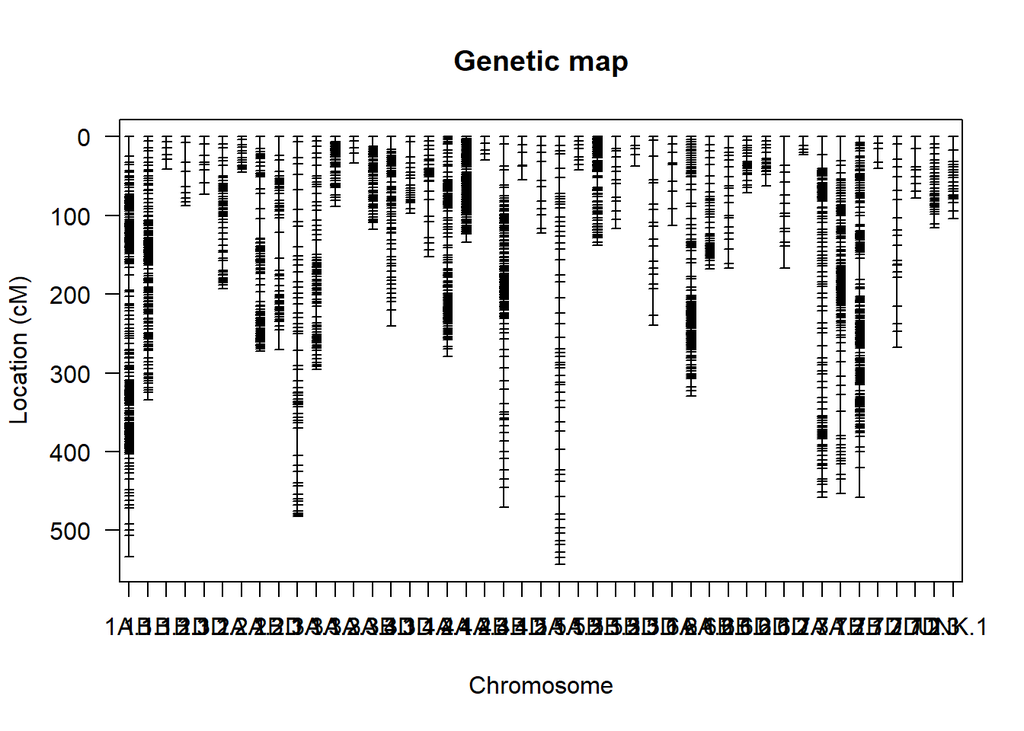

```r
plot.map(LZ8GBS)
```

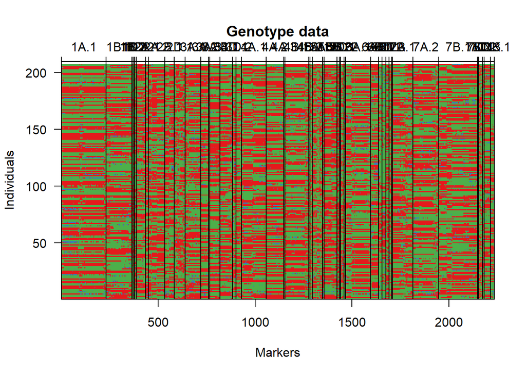

```r
geno.image(LZ8GBS)
```

Omit Skewed Markers with potential segregation distortion

```r
gt<-geno.table(LZ8GBS)
g <- gt[gt$P.value<0.05/totmar(LZ8GBS),]
datatable(g)
```

|  | chr | missing | AA | AB | BB | not.BB | not.AA | P.value |
| --- | --- | --- | --- | --- | --- | --- | --- | --- |
| A15328_3A_7A_70 | 1A.1 | 2 | 53 | 13 | 141 | 0 | 0 | 2.16142961748754e-09 |
| A23596_unk_70 | 1B.2 | 2 | 64 | 8 | 135 | 0 | 0 | 8.37306466790946e-07 |
| A1484_unk_70 | 1B.2 | 2 | 61 | 9 | 137 | 0 | 0 | 1.81695436496201e-07 |
| A13016_1B_70 | 1B.2 | 2 | 60 | 2 | 145 | 0 | 0 | 5.94016642196957e-11 |
| A15940_1B_100 | 1B.2 | 2 | 51 | 9 | 147 | 0 | 0 | 2.57121371975128e-11 |
| A9591_1B_100 | 1B.2 | 2 | 45 | 9 | 153 | 0 | 0 | 4.68744170095952e-14 |
| A576_1B_70 | 1B.2 | 2 | 67 | 8 | 132 | 0 | 0 | 6.85412274985824e-06 |
| A18104_1D_100 | 1D.1 | 2 | 60 | 15 | 132 | 0 | 0 | 1.32793685369236e-06 |
| A27014_1B_2B_100 | 2B.1 | 2 | 42 | 20 | 145 | 0 | 0 | 1.72190127929847e-13 |
| A17967_2D_100 | 2D.1 | 2 | 68 | 4 | 135 | 0 | 0 | 3.52302319595719e-07 |

[output cut: 82 more lines]

```r
drop <- c( "A15328_3A_7A_70" ,"A23596_unk_70" ,"A1484_unk_70" ,"A13016_1B_70" ,"A15940_1B_100" ,"A9591_1B_100" ,"A576_1B_70" ,"A18104_1D_100" ,"A27014_1B_2B_100","A17967_2D_100" ,"A13978_2D_70" ,"A25742_3A_100" ,"A18332_3A_70" ,"A12777_3D_100" ,"A273_4A_100" ,"A21245_4A_70" ,"A10491_4A_70" ,"A18377_4A_4B_70" ,"A25000_4B_70" ,"A25441_4B_100" ,"A4035_4D_100" ,"A18379_4D_100" ,"A18009_4D_70" ,"A19099_4D_7D_100","A16328_4D_70" ,"A11848_4D_70" ,"A12209_4D_100" ,"A27652_4D_100" ,"A21275_5A_100" ,"A25877_5A_100" ,"A25439_5A_70" ,"A25438_unk_70" ,"A20969_5A_70" ,"A8097_5A_100" ,"A19723_5A_100" ,"A11602_5A_100" ,"A7781_5A_100" ,"A11185_5D_100" ,"A27769_5D_100" ,"A16263_3D_5D_100","A18607_5D_100" ,"A25725_5D_100" ,"A1900_6A_70" ,"A11910_3A_6A_70" ,"A25264_6A_70" ,"A20866_6A_100" ,"A11585_6B_70" ,"A11967_6B_100" ,"A20255_6B_100" ,"A19959_6B_70" ,"A27878_6B_70" ,"A28179_6B_100" ,"A28536_6B_70" ,"A1460_6B_100" ,"A9811_6B_100" ,"A16328_6B_100" ,"A13442_6B_70" ,"A26650_3A_4B_70" ,"A8101_6B_100" ,"A7718_6B_6D_70" ,"A10138_6B_70" ,"A27566_unk_70" ,"A15195_unk_70" ,"A15639_unk_100" ,"A10596_6B_100" ,"A27867_unk_100" ,"A10599_unk_100" ,"A20619_6B_100" ,"A7070_6B_100" ,"A6713_1B_6B_70" ,"A22215_6B_100" ,"A499_5D_100" ,"A21788_6D_70" ,"A21995_6D_100" ,"A18389_6D_100" ,"A11691_6D_100" ,"A11316_6D_70" ,"A28649_6D_70" ,"A28881_6D_100" ,"A18071_6D_100" ,"A8016_7A_7D_100" ,"A6637_unk_70" ,"A7471_7A_100" ,"A12324_4B_7B_70" ,"A13388_7B_100" ,"A28147_7B_100" ,"A27851_7B_70" ,"A11842_7D_70" ,"A28228_7D_100" ,"A21486_7D_100" ,"A27928_7D_70" ,"A18989_unk_100","A7100_7A_70","A23150_unk_70")
LZ8GBS <- drop.markers(LZ8GBS, drop)
gt<-geno.table(LZ8GBS)
gt[gt$P.value<0.05/totmar(LZ8GBS),]
```

```
## [1] chr     missing AA      AB      BB      not.BB  not.AA  P.value
## <0 rows> (or 0-length row.names)
```

#### Composite Interval Mapping

Across all traits

```r
data_2 <- calc.genoprob(LZ8GBS, step=0)
out.cimE1PGD1 <- cim(data_2, pheno.col="E1D1",map.function=c("kosambi"),method=c("hk"))
out.cimE1PGD1$Trait <- ("E1PGD1")
out.cimE1PGD2 <- cim(data_2, pheno.col="E1D2",map.function=c("kosambi"),method=c("hk"))
out.cimE1PGD2$Trait <- ("E1PGD2")
out.cimE1PGD3 <- cim(data_2, pheno.col="E1D3",map.function=c("kosambi"),method=c("hk"))
out.cimE1PGD3$Trait <- ("E1PGD3")
out.cimE1PGD4 <- cim(data_2, pheno.col="E1D4",map.function=c("kosambi"),method=c("hk"))
out.cimE1PGD4$Trait <- ("E1PGD4")
out.cimE1PGD5 <- cim(data_2, pheno.col="E1D5",map.function=c("kosambi"),method=c("hk"))
out.cimE1PGD5$Trait <- ("E1PGD5")
out.cimE1GIavg <- cim(data_2, pheno.col="E1GI",map.function=c("kosambi"),method=c("hk"))
out.cimE1GIavg$Trait <- ("E1GIavg")
out.cimE2PGD1 <- cim(data_2, pheno.col="E2D1",map.function=c("kosambi"),method=c("hk"))
out.cimE2PGD1$Trait <- ("E2PGD1")
out.cimE2PGD2 <- cim(data_2, pheno.col="E2D2",map.function=c("kosambi"),method=c("hk"))
out.cimE2PGD2$Trait <- ("E2PGD2")
out.cimE2PGD3 <- cim(data_2, pheno.col="E2D3",map.function=c("kosambi"),method=c("hk"))
out.cimE2PGD3$Trait <- ("E2PGD3")
out.cimE2PGD4 <- cim(data_2, pheno.col="E2D4",map.function=c("kosambi"),method=c("hk"))
out.cimE2PGD4$Trait <- ("E2PGD4")
out.cimE2PGD5 <- cim(data_2, pheno.col="E2D5",map.function=c("kosambi"),method=c("hk"))
out.cimE2PGD5$Trait <- ("E2PGD5")
out.cimE2GIavg <- cim(data_2, pheno.col="E2GI",map.function=c("kosambi"),method=c("hk"))
out.cimE2GIavg$Trait <- ("E2GIavg")
out.cimE3PGD1 <- cim(data_2, pheno.col="E3D1",map.function=c("kosambi"),method=c("hk"))
out.cimE3PGD1$Trait <- ("E3PGD1")
out.cimE3PGD2 <- cim(data_2, pheno.col="E3D2",map.function=c("kosambi"),method=c("hk"))
out.cimE3PGD2$Trait <- ("E3PGD2")
out.cimE3PGD3 <- cim(data_2, pheno.col="E3D3",map.function=c("kosambi"),method=c("hk"))
out.cimE3PGD3$Trait <- ("E3PGD3")
out.cimE3PGD4 <- cim(data_2, pheno.col="E3D4",map.function=c("kosambi"),method=c("hk"))
out.cimE3PGD4$Trait <- ("E3PGD4")
out.cimE3PGD5 <- cim(data_2, pheno.col="E3D5",map.function=c("kosambi"),method=c("hk"))
out.cimE3PGD5$Trait <- ("E3PGD5")
out.cimE3GIavg <- cim(data_2, pheno.col="E3GI",map.function=c("kosambi"),method=c("hk"))
out.cimE3GIavg$Trait <- ("E3GIavg")

QTL.LZ8.ERA8 <- rbind(out.cimE1PGD1, out.cimE1PGD2, out.cimE1PGD3, out.cimE1PGD4, out.cimE1PGD5, out.cimE1GIavg, out.cimE2PGD1, out.cimE2PGD2, out.cimE2PGD3, out.cimE2PGD4, out.cimE2PGD5, out.cimE2GIavg,out.cimE3PGD1, out.cimE3PGD2, out.cimE3PGD3, out.cimE3PGD4, out.cimE3PGD5, out.cimE3GIavg)
# write.table(QTL.LZ8.ERA8, "./QTLLZ8All.txt", sep="\t")
```

```r
a<-scanone(LZ8GBS, method="hk", pheno.col = "E1D1", n.perm=1000)
c<-scanone(LZ8GBS, method="hk", pheno.col = "E1D2", n.perm=1000)
d<-scanone(LZ8GBS, method="hk", pheno.col = "E1D3", n.perm=1000)
e<-scanone(LZ8GBS, method="hk", pheno.col = "E1D4", n.perm=1000)
f<-scanone(LZ8GBS, method="hk", pheno.col = "E1D5", n.perm=1000)
g<-scanone(LZ8GBS, method="hk", pheno.col = "E1GI", n.perm=1000)
b1<-scanone(LZ8GBS, method="hk", pheno.col = "E2D1", n.perm=1000)
c1<-scanone(LZ8GBS, method="hk", pheno.col = "E2D2", n.perm=1000)
d1<-scanone(LZ8GBS, method="hk", pheno.col = "E2D3", n.perm=1000)
e1<-scanone(LZ8GBS, method="hk", pheno.col = "E2D4", n.perm=1000)
f1<-scanone(LZ8GBS, method="hk", pheno.col = "E2D5", n.perm=1000)
g1<-scanone(LZ8GBS, method="hk", pheno.col = "E2GI", n.perm=1000)
h<-scanone(LZ8GBS, method="hk", pheno.col = "E3D1", n.perm=1000)
i<-scanone(LZ8GBS, method="hk", pheno.col = "E3D2", n.perm=1000)
j<-scanone(LZ8GBS, method="hk", pheno.col = "E3D3", n.perm=1000)
k<-scanone(LZ8GBS, method="hk", pheno.col = "E3D4", n.perm=1000)
l<-scanone(LZ8GBS, method="hk", pheno.col = "E3D5", n.perm=1000)
m<-scanone(LZ8GBS, method="hk", pheno.col = "E3GI", n.perm=1000)
summary(a) #
summary(c) #
summary(d) #
summary(e) #
summary(f) #
summary(g) #
summary(b1) #
summary(c1) #
summary(d1) #
summary(e1) #
summary(f1) #
summary(g1) #
summary(h) #
summary(i) #
summary(j) #
summary(k) #
summary(l) #
summary(m) #
```

For graphing purposes only, add a column to give unique positions for each marker per chromosome.

```r
# uniqpos <- read.table("./GBS_UniquePos.txt",header=TRUE,na.string=c("", " ", "NA", "na"))
uniqpos$chr <- NULL
uniqpos$pos <- NULL
QTL.LZ8.ERA8 <- as.data.frame(QTL.LZ8.ERA8)
LZ8  <- cbind(QTL.LZ8.ERA8, uniqpos)
```

QTL Graph

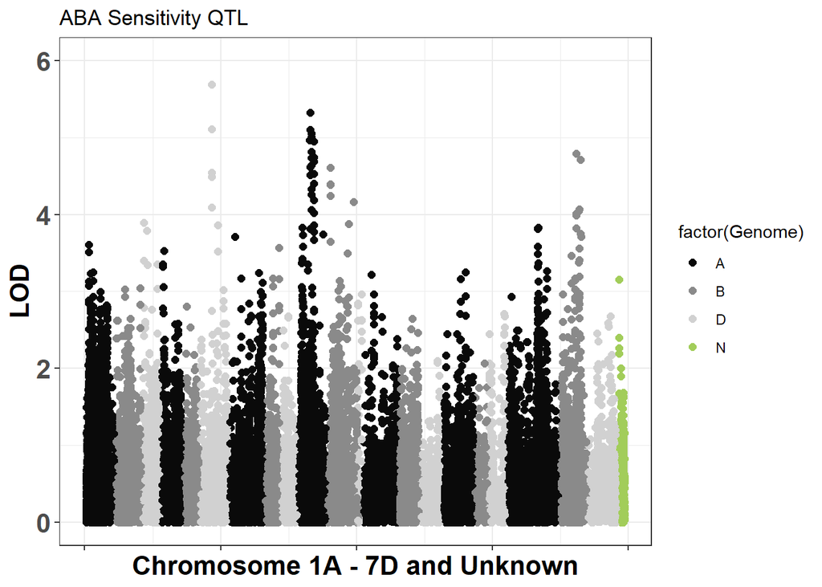

```r
ggplot(LZ8, aes(x=LZ8$order, y=LZ8$lod))+
  geom_point(aes(colour = factor(Genome)),size = 2)+ylim(0,6)+theme_bw()+ theme(axis.text = font,  axis.title = font, axis.text.x=element_blank())+ scale_color_manual(values=c("#0A0A0A", "#8A8A8A", "#D1D1D1","#A2CD5A"))+
  labs(x = "Chromosome 1A - 7D and Unknown" , y = "LOD", title="ABA Sensitivity QTL")
```

### Heading and Height

QTL Analysis

```r
data_2 <- calc.genoprob(LZ8GBS, step=0)
out.cimHeight <- cim(data_2, pheno.col="Height",map.function=c("kosambi"),method=c("hk"))
out.cimHeight$Trait <- ("Height")
out.cimHeading <- cim(data_2, pheno.col="Heading",map.function=c("kosambi"),method=c("hk"))
out.cimHeading$Trait <- ("Heading")
```

Calculate Significance Threshold

```r
a<-scanone(LZ8GBS, method="hk", pheno.col = "Heading", n.perm=1000)
summary(a) #4.43 5%
b<-scanone(LZ8GBS, method="hk", pheno.col = "Height", n.perm=1000)
summary(b) #4.38 5%
```

Graph the Manhatten Plot

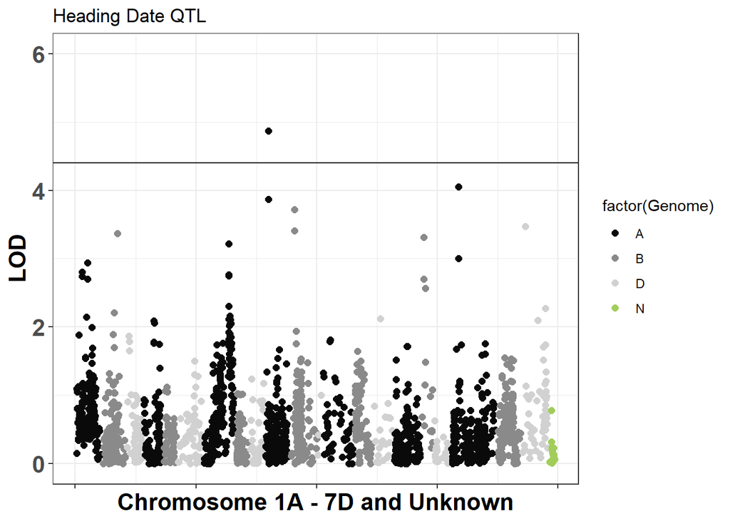

```r
QTL.LZ8.ERA8 <- as.data.frame(out.cimHeading)
QTLheadingLZ8  <- cbind(QTL.LZ8.ERA8, uniqpos)

ggplot(QTLheadingLZ8, aes(x=QTLheadingLZ8$order, y=QTLheadingLZ8$lod))+
  geom_point(aes(colour = factor(Genome)), size = 2)+theme_bw()+ylim(0,6)+
  theme(axis.text = font,  axis.title = font, axis.text.x=element_blank())+
  scale_color_manual(values=c("#0A0A0A", "#8A8A8A", "#D1D1D1","#A2CD5A"))+ geom_hline(aes(yintercept = 4.4))+
  labs(x = "Chromosome 1A - 7D and Unknown" , y = "LOD", title="Heading Date QTL")
```

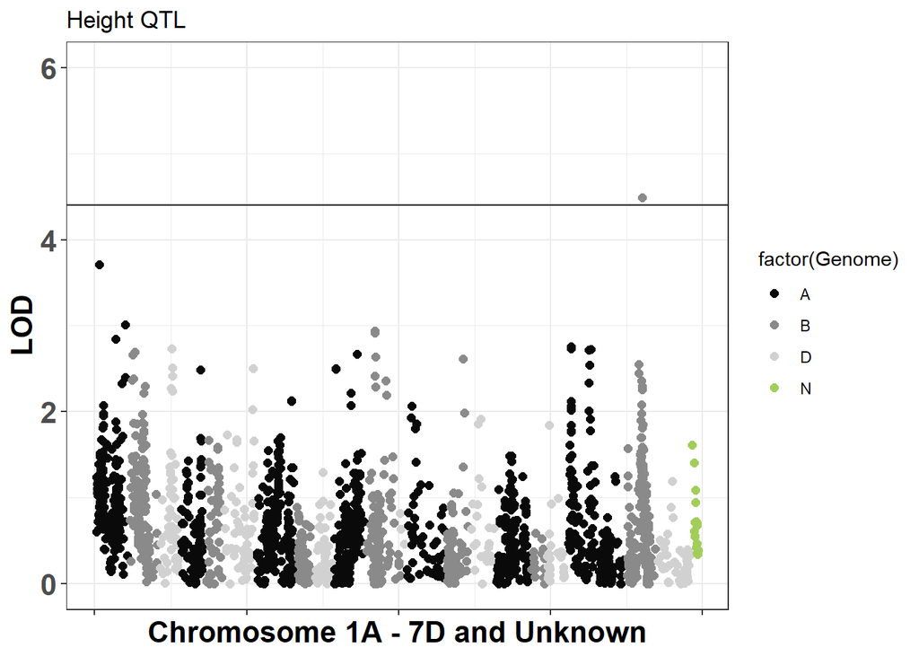

```r
QTL.LZ8.ERA8 <- as.data.frame(out.cimHeight)
QTLheightLZ8  <- cbind(QTL.LZ8.ERA8, uniqpos)

ggplot(QTLheightLZ8, aes(x=QTLheightLZ8$order, y=QTLheightLZ8$lod))+
  geom_point(aes(colour = factor(Genome)), size = 2)+theme_bw()+ylim(0,6) +
  theme(axis.text = font,  axis.title = font, axis.text.x=element_blank())+
  scale_color_manual(values=c("#0A0A0A", "#8A8A8A", "#D1D1D1","#A2CD5A"))+ geom_hline(aes(yintercept = 4.4))+
  labs(x = "Chromosome 1A - 7D and Unknown" , y = "LOD", title="Height QTL")
```

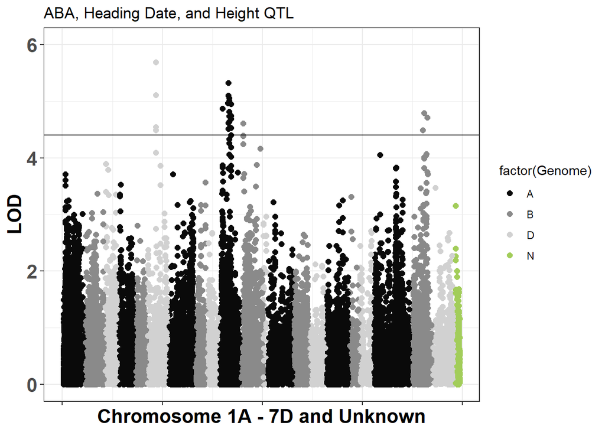

```r
# uniqposAHH <- read.table("./GBS_UniquePos_ABAHeadHei.txt",header=TRUE,na.string=c("", " ", "NA", "na"))
uniqposAHH$chr <- NULL
uniqposAHH$pos <- NULL
QTL.LZ8.ERA8 <- rbind(out.cimE1PGD1, out.cimE1PGD2, out.cimE1PGD3, out.cimE1PGD4,
                      out.cimE1PGD5, out.cimE1GIavg, out.cimE2PGD1, out.cimE2PGD2,
                      out.cimE2PGD3, out.cimE2PGD4, out.cimE2PGD5, out.cimE2GIavg,
                      out.cimE3PGD1, out.cimE3PGD2, out.cimE3PGD3, out.cimE3PGD4,
                      out.cimE3PGD5, out.cimE3GIavg, out.cimHeight, out.cimHeading )
QTL.LZ8.ERA8 <- as.data.frame(QTL.LZ8.ERA8)
QTL.LZ8  <- cbind(QTL.LZ8.ERA8, uniqposAHH)
ggplot(QTL.LZ8, aes(x=QTL.LZ8$order, y=QTL.LZ8$lod))+
  geom_point(aes(colour = factor(Genome)),size = 2)+ylim(0,6)+theme_bw()+
  theme(axis.text = font,  axis.title = font, axis.text.x=element_blank())+
  scale_color_manual(values=c("#0A0A0A", "#8A8A8A", "#D1D1D1","#A2CD5A")) + geom_hline(aes(yintercept = 4.4))+
  labs(x = "Chromosome 1A - 7D and Unknown" , y = "LOD", title="ABA, Heading Date, and Height QTL")
```

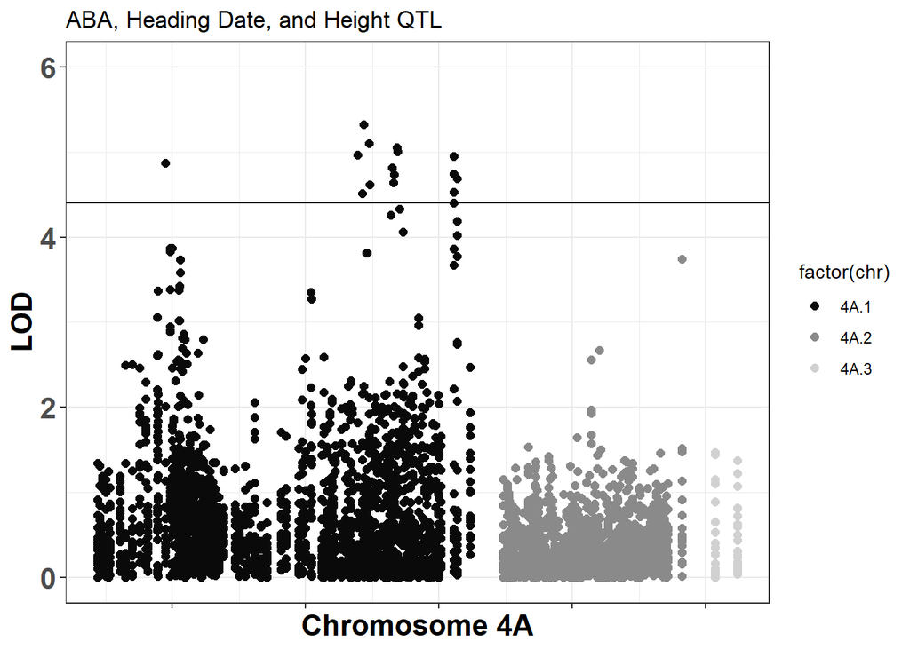

```r
QTL.LZ8.4A <-  subset(QTL.LZ8 ,  QTL.LZ8$chr=="4A.1" | QTL.LZ8$chr=="4A.2" | QTL.LZ8$chr=="4A.3" )
ggplot(QTL.LZ8.4A, aes(x=QTL.LZ8.4A$order, y=QTL.LZ8.4A$lod))+
  geom_point(aes(colour = factor(chr)),size = 2)+ylim(0,6)+theme_bw()+
  theme(axis.text = font,  axis.title = font, axis.text.x=element_blank())+
  scale_color_manual(values=c("#0A0A0A", "#8A8A8A", "#D1D1D1")) + geom_hline(aes(yintercept = 4.4))+
  labs(x = "Chromosome 4A" , y = "LOD", title="ABA, Heading Date, and Height QTL")
```

List of Significant QTL on Chromosome 4A

```r
QTL.LZ8.4A %>%
  mutate(lod = round(lod,2)) %>%
  filter(lod > 4.4) %>%
  arrange(str_extract(chr, '^.'), pos) %>%
  dplyr::select(Marker, chr, pos,  Trait, lod)  %>%
  kable(caption = "Table 1: Summary of QTL with a LOD > 4.4 on Chromosome 4A") %>%
  kable_styling(bootstrap_options = c("striped", "hover"), full_width = F)
```

Table 1: Summary of QTL with a LOD > 4.4 on Chromosome 4A

| Marker | chr | pos | Trait | lod |
| --- | --- | --- | --- | --- |
| A23913_4A_10019 | 4A.1 | 50.930 | Heading | 4.87 |
| A1512_4A_5D_10012 | 4A.1 | 194.875 | E3PGD1 | 4.96 |
| A3059_4A_5B_10012 | 4A.1 | 198.689 | E3PGD1 | 4.51 |
| A11335_4A_10012 | 4A.1 | 199.746 | E3PGD1 | 5.32 |
| A12321_4A_7012 | 4A.1 | 203.752 | E3PGD1 | 5.10 |
| A12683_4A_10012 | 4A.1 | 203.883 | E3PGD1 | 4.61 |
| A14030_4A_1006 | 4A.1 | 220.988 | E2PGD1 | 4.81 |
| A25258_4A_1006 | 4A.1 | 221.643 | E2PGD1 | 4.64 |
| A24819_4A_706 | 4A.1 | 222.432 | E2PGD1 | 4.73 |
| A16612_4A_1006 | 4A.1 | 224.180 | E2PGD1 | 5.05 |
| A15895_4A_1006 | 4A.1 | 225.103 | E2PGD1 | 5.01 |
| A28975_4A_701 | 4A.1 | 266.800 | E1PGD2 | 4.95 |
| A28975_4A_703 | 4A.1 | 266.800 | E1PGD4 | 4.74 |
| A28975_4A_705 | 4A.1 | 266.800 | E1GIavg | 4.53 |
| A29203_4A_1001 | 4A.1 | 269.410 | E1PGD2 | 4.69 |

## Otis/ZakERA8 F2:3

The `OZ8` dataset contains the Otis/ZakERA8 F2: F3 genotypic data, phenotypic data, and marker positions on chromosome 4A.

```r
OZ8<-read.cross("csv",".","./OZ8_SNP6-SNP29.csv",na.strings=c("-","NA","."),BC.gen=0, F.gen=2)
```

```r
OZ8
```

```
##   This is an object of class "cross".
##   It is too complex to print, so we provide just this summary.
##     BC(0)F(2) cross
##
##     No. individuals:    108
##
##     No. phenotypes:     7
##     Percent phenotyped: 100 98.1 98.1 98.1 98.1 98.1 98.1
##
##     No. chromosomes:    1
##         Autosomes:      4A
##
##     Total markers:      4
##     No. markers:        4
##     Percent genotyped:  99.5
##     Genotypes (%):      AA:24.0  AB:49.1  BB:27.0  not BB:0.0  not AA:0.0
```

```r
# geno.image(OZ8)
# summary(OZ8$pheno)
```

**Check for skewed markers**

```r
gt<-geno.table(OZ8)
gt[gt$P.value<0.05/totmar(OZ8),]
```

```
## [1] chr     missing AA      AB      BB      not.BB  not.AA  P.value
## <0 rows> (or 0-length row.names)
```

No markers are skewed.  
The phenotypes include percent germination (`PG`) is separated by day (d1…d5) and Germination Index (`GI`) is calculated over all 5 days:  
> PG_d1, PG_d2, PG_d3, PG_d4, PG_d5, GI

#### Compite Interval Mapping

```r
data_2 <- calc.genoprob(OZ8, step=0)
out.cimGI <- cim(data_2, pheno.col="GI",map.function=c("kosambi"),method=c("hk"))
a<-scanone(OZ8, method="hk", pheno.col = "GI", n.perm=1000)
summary(a)

out.cimd5 <- cim(data_2, pheno.col="PG_d5",map.function=c("kosambi"),method=c("hk"))
out.cimd4 <- cim(data_2, pheno.col="PG_d4",map.function=c("kosambi"),method=c("hk"))
out.cimd3 <- cim(data_2, pheno.col="PG_d3",map.function=c("kosambi"),method=c("hk"))
out.cimd2 <- cim(data_2, pheno.col="PG_d2",map.function=c("kosambi"),method=c("hk"))
out.cimd1 <- cim(data_2, pheno.col="PG_d1",map.function=c("kosambi"),method=c("hk"))
```

#### Wrangle Results

```r
out.cimd5$Pheno <- "d5"
out.cimd4$Pheno <- "d4"
out.cimd3$Pheno <- "d3"
out.cimd2$Pheno <- "d2"
out.cimd1$Pheno <- "d1"
out.cimGI$Pheno <- "GI"
Otera8 <- rbind(out.cimGI ,out.cimd5,out.cimd4,out.cimd3,out.cimd2,out.cimd1 )
```

#### Graph Results

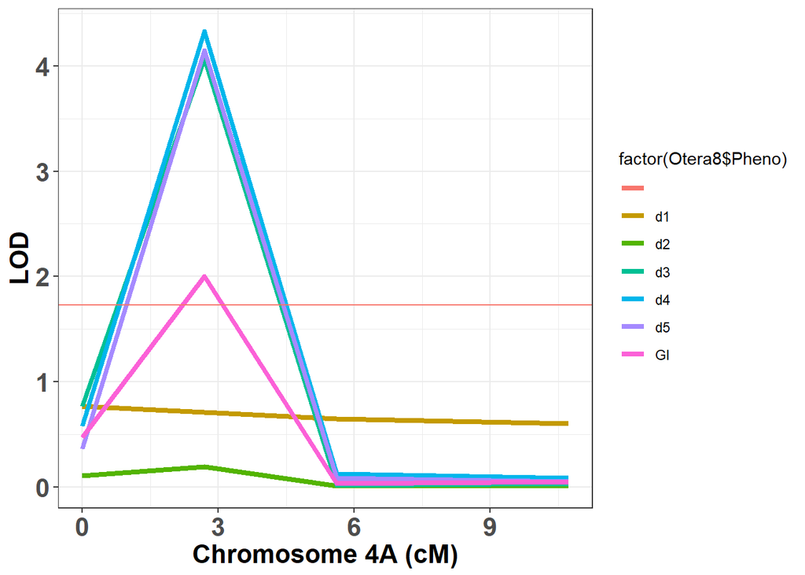

```r
ggplot(Otera8, aes(x=Otera8$pos, y=Otera8$lod, colour = factor(Otera8$Pheno)))+
  geom_line(size = 1.5)+
  theme_bw()+ theme(axis.text = font,  axis.title = font)+
  geom_hline(aes(yintercept = 1.73, colour = ""))+
  labs(x = "Chromosome 4A (cM)", y = "LOD")
```

```r
out.cimGI2 <- rbind(out.cimGI, out.cimd5)
ggplot(out.cimGI2, aes(x=out.cimGI2$pos, y=out.cimGI2$lod))+
  geom_line(aes(colour = factor(Pheno)),size = 1)+
  theme_bw()+ theme(axis.text = font,  axis.title = font)+
  geom_hline(aes(yintercept = 1.78))+
  labs(x = "Chromosome 4A (cM)", y = "LOD")  +
  ylim (0,10) +xlim (0,11)+
  scale_color_manual(values=c("#CD6600","#FFB90F")) #+ theme(legend.position="none")
```

## Figure 3c

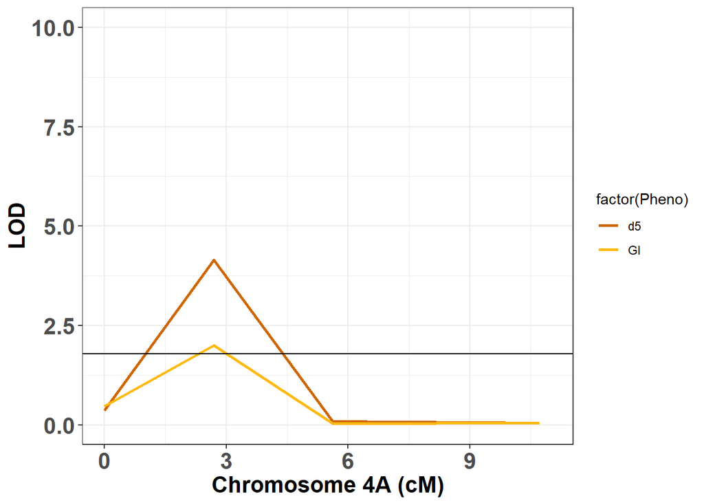